# Data pre-processing for WHO (World Health Organization) Data

## Setup

We have loaded below necessary packages to produce this report:

```r
library(readr)
library(tidyr)
library(dplyr)
library(Hmisc)
library(outliers)
```

## Read WHO Data

To read the WHO data in R, we have used `read.csv()` function from `utils` package. We stored this data in a data frame, `dataSetWHO`. Also, to avoid auto factorization, we set the option `StringAsFactors` as `FALSE`. To checked if data has been correctly imported, we used `head()` function from `utils` package.

```r
#Import data
dataSetWHO <- read.csv("WHO.csv", stringsAsFactors = FALSE)

#Check dimensions of dataSetWHO
dataSetWHO %>% dim()
```

```
## [1] 7240   60
```

```r
#Check data in dataSetWHO
dataSetWHO %>% head()
```

|  | country | iso2 | iso3 | year | new_sp_m014 | new_sp_m1524 | new_sp_m2534 | new_sp_m3544 | new_sp_m4554 | new_sp_m5564 | new_sp_m65 | new_sp_f014 | new_sp_f1524 | new_sp_f2534 | new_sp_f3544 | new_sp_f4554 | new_sp_f5564 | new_sp_f65 | new_sn_m014 | new_sn_m1524 | new_sn_m2534 | new_sn_m3544 | new_sn_m4554 | new_sn_m5564 | new_sn_m65 | new_sn_f014 | new_sn_f1524 | new_sn_f2534 | new_sn_f3544 | … |
| --- | --- | --- | --- | --- | --- | --- | --- | --- | --- | --- | --- | --- | --- | --- | --- | --- | --- | --- | --- | --- | --- | --- | --- | --- | --- | --- | --- | --- | --- | --- |
| 1 | Afghanistan | AF | AFG | 1980 | NA | NA | NA | NA | NA | NA | NA | NA | NA | NA | NA | NA | NA | NA | NA | NA | NA | NA | NA | NA | NA | NA | NA | NA | NA | … |
| 2 | Afghanistan | AF | AFG | 1981 | NA | NA | NA | NA | NA | NA | NA | NA | NA | NA | NA | NA | NA | NA | NA | NA | NA | NA | NA | NA | NA | NA | NA | NA | NA | … |
| 3 | Afghanistan | AF | AFG | 1982 | NA | NA | NA | NA | NA | NA | NA | NA | NA | NA | NA | NA | NA | NA | NA | NA | NA | NA | NA | NA | NA | NA | NA | NA | NA | … |
| 4 | Afghanistan | AF | AFG | 1983 | NA | NA | NA | NA | NA | NA | NA | NA | NA | NA | NA | NA | NA | NA | NA | NA | NA | NA | NA | NA | NA | NA | NA | NA | NA | … |
| 5 | Afghanistan | AF | AFG | 1984 | NA | NA | NA | NA | NA | NA | NA | NA | NA | NA | NA | NA | NA | NA | NA | NA | NA | NA | NA | NA | NA | NA | NA | NA | NA | … |
| 6 | Afghanistan | AF | AFG | 1985 | NA | NA | NA | NA | NA | NA | NA | NA | NA | NA | NA | NA | NA | NA | NA | NA | NA | NA | NA | NA | NA | NA | NA | NA | NA | … |

## Tidy Task 1:

**Step 1:** Using the `gather()` function from `tidyr` package, we gathered the data as required and stored it in a new data frame `dataSetWHO_Task1`.

```r
dataSetWHO_Task1 <- dataSetWHO %>%
                    gather('new_sp_m014':'new_rel_f65',
                           key = "code", value = "value")
```

**Step 2:** To confirm the dimensions, we used `dim()` function from `base` package. From the output, we confirmed `dataSetWHO_Task1` has correct required dimensions, i.e, 405440 rows and 6 columns.

```r
dataSetWHO_Task1 %>% dim()
```

```
## [1] 405440      6
```

**Step 3:** We used `head()` function from `utils` package to confirm if data has been correctly saved in `dataSetWHO_Task1`.

```r
dataSetWHO_Task1 %>% head()
```

|  | country | iso2 | iso3 | year | code | value |
| --- | --- | --- | --- | --- | --- | --- |
| 1 | Afghanistan | AF | AFG | 1980 | new_sp_m014 | NA |
| 2 | Afghanistan | AF | AFG | 1981 | new_sp_m014 | NA |
| 3 | Afghanistan | AF | AFG | 1982 | new_sp_m014 | NA |
| 4 | Afghanistan | AF | AFG | 1983 | new_sp_m014 | NA |
| 5 | Afghanistan | AF | AFG | 1984 | new_sp_m014 | NA |
| 6 | Afghanistan | AF | AFG | 1985 | new_sp_m014 | NA |

## Tidy Task 2:

**Step 1:** Using `separate()` function from `tidyr` package, we first separated `code` column from `dataSetWHO_Task1` into `new`, `var` and `temp` and stored this in a temporary data frame `dataSetWHO_Task2_Temp`.

```r
dataSetWHO_Task2_Temp <- dataSetWHO_Task1 %>% separate(code, into = c("new", "var", "temp"), sep = "_")
```

**Step 2:** The `temp` column in `dataSetWHO_Task2_Temp` had data for sex and age, but in data, delimiting character was not present. To split `temp` into `sex` and `age`, we set the option `sep` to 1. 1 here specifies the position at which the column needs to separated.

```r
dataSetWHO_Task2 <- dataSetWHO_Task2_Temp %>% separate(temp, into = c("sex", "age"), sep = 1)
```

**Step 3:** After execution of above code, we used the `dim()` function from `base` package to check the dimensions. From output we confirmed the dimension of `dataSetWHO_Task2` to be as required, i.e., 405440 rows and 9 columns.

```r
dataSetWHO_Task2 %>% dim()
```

```
## [1] 405440      9
```

**Step 4:** In this step, to make sure correct data has been loaded in `dataSetWHO_Task2`, we used `head()` function from `utils` package.

```r
dataSetWHO_Task2 %>% head()
```

|  | country | iso2 | iso3 | year | new | var | sex | age | value |
| --- | --- | --- | --- | --- | --- | --- | --- | --- | --- |
| 1 | Afghanistan | AF | AFG | 1980 | new | sp | m | 014 | NA |
| 2 | Afghanistan | AF | AFG | 1981 | new | sp | m | 014 | NA |
| 3 | Afghanistan | AF | AFG | 1982 | new | sp | m | 014 | NA |
| 4 | Afghanistan | AF | AFG | 1983 | new | sp | m | 014 | NA |
| 5 | Afghanistan | AF | AFG | 1984 | new | sp | m | 014 | NA |
| 6 | Afghanistan | AF | AFG | 1985 | new | sp | m | 014 | NA |

## Tidy Task 3:

```r
dataSetWHO_Task3 <- spread(dataSetWHO_Task2, key = var, value = value)
```

**Step 2:** To check if `dataSetWHO_Task3` has required dimensions, we used `dim()` function from `base` package. From the output, we confirmed dimensions of `dataSetWHO_Task3` to be as required, i.e, 101360 rows and 11 columns.

```r
dataSetWHO_Task3 %>% dim()
```

```
## [1] 101360     11
```

**Step 3:** In this step, to confirm data has been stored correctly in `dataSetWHO_Task3`, we used `head()` function from `utils` package.

```r
dataSetWHO_Task3 %>% head()
```

|  | country | iso2 | iso3 | year | new | sex | age | ep | rel | sn | sp |
| --- | --- | --- | --- | --- | --- | --- | --- | --- | --- | --- | --- |
| 1 | Afghanistan | AF | AFG | 1980 | new | m | 014 | NA | NA | NA | NA |
| 2 | Afghanistan | AF | AFG | 1981 | new | m | 014 | NA | NA | NA | NA |
| 3 | Afghanistan | AF | AFG | 1982 | new | m | 014 | NA | NA | NA | NA |
| 4 | Afghanistan | AF | AFG | 1983 | new | m | 014 | NA | NA | NA | NA |
| 5 | Afghanistan | AF | AFG | 1984 | new | m | 014 | NA | NA | NA | NA |
| 6 | Afghanistan | AF | AFG | 1985 | new | m | 014 | NA | NA | NA | NA |

## Tidy Task 4:

**Step 1:** To complete this task, we first took the data from previous step into a new data frame, `dataSetWHO_Task4`.

```r
dataSetWHO_Task4 <- dataSetWHO_Task3
```

**Step 2:** In this step, we converted `sex` variable from `character` to `factor` using the `mutate()` function from `dplyr` package. We also converted `age` variable into `factor` using the same `mutate()` function from `dplyr` package. Here we reordered and relabled the labels for variable `age`. We then checked the levels of `sex` and `age` variables using `levels()` function from `base` package. From the output, we confirmed conversion has been done as required.

```r
#Convert to factor, relabel and reorder factors for age
dataSetWHO_Task4 <- dataSetWHO_Task4 %>% mutate(sex = factor(sex, levels = c("m", "f")),
                                                age = factor(age,
                                                      levels = c("014", "1524", "2534", "3544", "4554", "5564", "65"),
                                                      labels = c("<15", "15-24", "25-34", "35-44", "45-54", "55-64", "65>="),
                                                      ordered = TRUE))

#Check levels of sex
dataSetWHO_Task4$sex %>% levels()
```

```
## [1] "m" "f"
```

```r
#Check levels of age
dataSetWHO_Task4$age %>% levels()
```

```
## [1] "<15"   "15-24" "25-34" "35-44" "45-54" "55-64" "65>="
```

**Step 3:** In this step, to confirm correct execution of above steps, we checked the dimensions and data present in `dataSetWHO_Task4` using `dim()` and `head()` functions from `base` and `utils` package respectively.

```r
#Check dimension of dataSetWHO_Task4
dataSetWHO_Task4 %>% dim()
```

```
## [1] 101360     11
```

```r
#Check data in dataSetWHO_Task4
dataSetWHO_Task4 %>% head()
```

|  | country | iso2 | iso3 | year | new | sex | age | ep | rel | sn | sp |
| --- | --- | --- | --- | --- | --- | --- | --- | --- | --- | --- | --- |
| 1 | Afghanistan | AF | AFG | 1980 | new | m | <15 | NA | NA | NA | NA |
| 2 | Afghanistan | AF | AFG | 1981 | new | m | <15 | NA | NA | NA | NA |
| 3 | Afghanistan | AF | AFG | 1982 | new | m | <15 | NA | NA | NA | NA |
| 4 | Afghanistan | AF | AFG | 1983 | new | m | <15 | NA | NA | NA | NA |
| 5 | Afghanistan | AF | AFG | 1984 | new | m | <15 | NA | NA | NA | NA |
| 6 | Afghanistan | AF | AFG | 1985 | new | m | <15 | NA | NA | NA | NA |

## Task 5: Filter & Select

**Step 1:** To drop the redundant columns `iso2` and `new`, we used `select()` from `dplyr` package. We selected the data from `dataSetWHO_Task4` excluding columns `iso2` and `new` and stored it in a temporary data frame `dataSetWHO_Task5_Temp`.

```r
dataSetWHO_Task5_Temp <- dataSetWHO_Task4 %>% select(-(iso2)) %>% select(-(new))
```

**Step 2:** In this step, we filtered the data in `dataSetWHO_Task5_Temp` for 3 countries, viz., **Chad**, **Kyrgyzstan** and **Zambia** and stored it in a new data frame `WHO_subset`. We then confirmed if `WHO_subset` has data for required countries using `table()` function from `base` package. From the output, data only for **Chad**, **Kyrgyzstan** and **Zambia** countries is present in `WHO_subset`.

```r
#Filter data
WHO_subset <- dataSetWHO_Task5_Temp %>% filter(country == "Chad" |
                                               country == "Kyrgyzstan" |
                                               country == "Zambia")

#Check data
WHO_subset$country %>% table()
```

```
## .
##       Chad Kyrgyzstan     Zambia
##        476        476        476
```

**Step 3:** Lastly, we checked the dimensions and data in `WHO_subset` using `dim()` and `head()` functions from `base` and `utils` package respectively.

```r
#Check dimensions of WHO_subset
WHO_subset %>% dim()
```

```
## [1] 1428    9
```

```r
#Check data in WHO_subset
WHO_subset %>% head()
```

|  | country | iso3 | year | sex | age | ep | rel | sn | sp |
| --- | --- | --- | --- | --- | --- | --- | --- | --- | --- |
| 1 | Chad | TCD | 1980 | m | <15 | NA | NA | NA | NA |
| 2 | Chad | TCD | 1981 | m | <15 | NA | NA | NA | NA |
| 3 | Chad | TCD | 1982 | m | <15 | NA | NA | NA | NA |
| 4 | Chad | TCD | 1983 | m | <15 | NA | NA | NA | NA |
| 5 | Chad | TCD | 1984 | m | <15 | NA | NA | NA | NA |
| 6 | Chad | TCD | 1985 | m | <15 | NA | NA | NA | NA |

## Read Species and Surveys data sets

We imported the species and surveys data and stored it in data frames `species` and `surveys` respectively. For both the datasets, we set `stringsAsFactors` option as `FALSE` to avoid auto factorization.

```r
#Import Species data
species <- read.csv("species.csv", stringsAsFactors = FALSE)

#Import Surveys data
surveys <- read.csv("surveys.csv", stringsAsFactors = FALSE)
```

To checked if data has been correctly imported in `species` and `surveys`, we used `head()` function from `utils` package. From the output, data has been correctly imported.

```r
#Check dimensions of Species
species %>% dim()
```

```
## [1] 54  4
```

```r
#Check data in Species
species %>% head()
```

|  | species_id | genus | species | taxa |
| --- | --- | --- | --- | --- |
| 1 | AB | Amphispiza | bilineata | Bird |
| 2 | AH | Ammospermophilus | harrisi | Rodent |
| 3 | AS | Ammodramus | savannarum | Bird |
| 4 | BA | Baiomys | taylori | Rodent |
| 5 | CB | Campylorhynchus | brunneicapillus | Bird |
| 6 | CM | Calamospiza | melanocorys | Bird |

```r
#Check dimensions of Surveys
surveys %>% dim()
```

```
## [1] 35549     8
```

```r
#Check data in Surveys
surveys %>% head()
```

|  | record_id | month | day | year | species_id | sex | hindfoot_length | weight |
| --- | --- | --- | --- | --- | --- | --- | --- | --- |
| 1 | 1 | 7 | 16 | 1977 | NL | M | 32 | NA |
| 2 | 2 | 7 | 16 | 1977 | NL | M | 33 | NA |
| 3 | 3 | 7 | 16 | 1977 | DM | F | 37 | NA |
| 4 | 4 | 7 | 16 | 1977 | DM | M | 36 | NA |
| 5 | 5 | 7 | 16 | 1977 | DM | M | 35 | NA |
| 6 | 6 | 7 | 16 | 1977 | PF | M | 14 | NA |

## Task 6: Join

**Step 1:** We added the columns `genus`, `species`, `taxa` from `species` data frame to the `surveys` data frame using `inner_join()` function from `dplyr` package and stored the data that was combined into a new data frame `surveys_combined`. We used **inner join** to exclude all the records from both the tables where `species_id` was `NA`. This ensured that each record in `surveys_combined` was associated with a `species_id`.

We specifically decided to not go for left join or right join or full join. If we had selected any of these joins, records where `species` column had `NA` values would be included in `surveys_combined`. In Task 8, we had to find count of `NA` values present in `weight` column for each species. If there were records where species values were `NA`, along with the names of species we would have got another group named NA for which the count of `NA` weights were calculated.

```r
surveys_combined <- surveys %>% inner_join(species, by = "species_id")
```

**Step 2:** To check if `surveys_combined` had all the required columns, we used `colnames()` function from `base` package. From the output, we confirmed that the 3 required columns from `species` data frame have been successfully added to columns of `surveys` data frame.

```r
surveys_combined %>% colnames()
```

```
##  [1] "record_id"       "month"           "day"             "year"
##  [5] "species_id"      "sex"             "hindfoot_length" "weight"
##  [9] "genus"           "species"         "taxa"
```

**Step 3:** We checked the dimensions and data for `surveys_combined` using `dim()` and `head()` functions from `base` and `utils` packages respectively.

```r
#Check dimensions of surveys_combined
surveys_combined %>% dim()
```

```
## [1] 34786    11
```

```r
#Check data in surveys_combined
surveys_combined %>% head()
```

|  | record_id | month | day | year | species_id | sex | hindfoot_length | weight | genus | species | taxa |
| --- | --- | --- | --- | --- | --- | --- | --- | --- | --- | --- | --- |
| 1 | 1 | 7 | 16 | 1977 | NL | M | 32 | NA | Neotoma | albigula | Rodent |
| 2 | 2 | 7 | 16 | 1977 | NL | M | 33 | NA | Neotoma | albigula | Rodent |
| 3 | 3 | 7 | 16 | 1977 | DM | F | 37 | NA | Dipodomys | merriami | Rodent |
| 4 | 4 | 7 | 16 | 1977 | DM | M | 36 | NA | Dipodomys | merriami | Rodent |
| 5 | 5 | 7 | 16 | 1977 | DM | M | 35 | NA | Dipodomys | merriami | Rodent |
| 6 | 6 | 7 | 16 | 1977 | PF | M | 14 | NA | Perognathus | flavus | Rodent |

## Task 7: Calculate

For this task, we calculated the mean weight and mean hinfoot length of **spectabilis** species for each month, irrespective of the year. We stored the data of month and its corresponding mean weight and mean hindfoot length in a dataframe, `mean_weight_hindfoot_length`.

```r
mean_weight_hindfoot_length <- surveys_combined %>%
               filter(species == "spectabilis") %>%
               group_by(month) %>%
               summarise(mean_weight = mean(weight, na.rm = TRUE),
                         mean_hindfoot_length = mean(hindfoot_length, na.rm = TRUE)) %>%
               round(2)
```

The output below displays the dimensions `mean_weight_hindfoot_length`. From the output, we confirmed there are 12 rows, 1 row for each month.

```r
mean_weight_hindfoot_length %>% dim()
```

```
## [1] 12  3
```

The month-wise mean weight and mean hindfoot length of `spectabilis` species are as below.

```r
mean_weight_hindfoot_length
```

| month | mean_weight | mean_hindfoot_length |
| --- | --- | --- |
| 1 | 130.75 | 49.86 |
| 2 | 126.07 | 50.37 |
| 3 | 121.43 | 49.93 |
| 4 | 116.20 | 49.64 |
| 5 | 112.75 | 49.60 |
| 6 | 111.60 | 50.22 |
| 7 | 112.41 | 49.90 |
| 8 | 120.14 | 49.83 |
| 9 | 124.95 | 50.20 |
| 10 | 126.94 | 50.18 |

[output cut: 2 more lines]

## Task 8: Missing Values

**Step 1:** For Task 8, we selected the data of year **1990** from `surveys_combined` dataframe and stored it in a new data frame `surveys_combined_year`.

```r
surveys_combined_year <- surveys_combined %>% filter(year == 1990)
```

**Step 2:** In this step, we used `group_by()` & `summarise()` function from `dplyr` package and `sum()` & `is.na()` functions from `base` package, to find total number of `NA` values in `weight` column for each species. We stored this data in a temporary data frame `surveys_combined_year_temp`. The output for this step shows the count of `NA` values present under each species.

```r
surveys_combined_year_temp <- surveys_combined_year %>%
                              group_by(species) %>%
                              summarise(na_count_weight = sum(is.na(weight)))
```

The dimensions of `surveys_combined_year_temp` tell us there are total of 20 species.

```r
surveys_combined_year_temp %>% dim()
```

```
## [1] 20  2
```

The count of `NA` values in `weight` column for few of the species is as below.

```r
surveys_combined_year_temp %>% head()
```

| species | na_count_weight |
| --- | --- |
| albigula | 0 |
| bilineata | 27 |
| chlorurus | 8 |
| eremicus | 2 |
| flavus | 0 |
| fulvescens | 0 |

**Step 3:** In this step, we replaced `NA` values in `weight` column with the mean weight for its respective species. We used `group_by()` and `mutate()` functions from `dplyr` package along with `impute()` function from `Hmisc` package.

```r
surveys_weight_imputed <- surveys_combined_year %>%
                          group_by(species) %>%
                          mutate(weight = weight %>% impute(fun = mean))
```

**Step 4:** To verify if imputation was successful, we considered 2 records from different species. First record had `record_id` = `17154` and `species` = `eremicus`. Other record had `record_id` = `18077` and `species` = `megalotis`.

Let us consider first record which is of `eremicus` species type. In `surveys_combined_year`, the value in `weight` column for `record_id` = `17154` is `NA`.

```r
surveys_combined_year %>% filter(record_id == 17154) %>% select(record_id, species, weight)
```

| record_id | species | weight |
| --- | --- | --- |
| 17154 | eremicus | NA |

The mean weight for `eremicus` species is `21.67123`.

```r
(surveys_combined_year %>% filter(species == "eremicus"))$weight %>% mean(na.rm = TRUE)
```

```
## [1] 21.67123
```

In `surveys_weight_imputed`, the value in `weight` column for `record_id` = `17154` is `21.7`.

```r
surveys_weight_imputed %>% filter(record_id == 17154) %>% select(record_id, species, weight)
```

| record_id | species | weight |
| --- | --- | --- |
| 17154 | eremicus | 21.67123 |

From this we confirmed that the value had been correctly imputed for our 1st record under consideration.

For second record, in `surveys_combined_year`, the value in `weight` for `record_id` = `18077` is `NA`.

```r
surveys_combined_year %>% filter(record_id == 18077) %>% select(record_id, species, weight)
```

| record_id | species | weight |
| --- | --- | --- |
| 18077 | megalotis | NA |

The mean weight for `megalotis` species is `10.30568`.

```r
(surveys_combined_year %>% filter(species == "megalotis"))$weight %>% mean(na.rm = TRUE)
```

```
## [1] 10.30568
```

In `surveys_weight_imputed`, the value in `weight` column for `record_id` = `18077` is `10.3`.

```r
surveys_weight_imputed %>% filter(record_id == 18077) %>% select(record_id, species, weight)
```

| record_id | species | weight |
| --- | --- | --- |
| 18077 | megalotis | 10.30568 |

From this, we again confirmed that value has been correctly imputed.

## Task 9: Special Values

**Step 1:** We first checked for `Inf` or `-Inf` values in `weight` column of `surveys_weight_imputed` using `is.infinite()` function from `base` package. From the output, there are no `Inf` or `-Inf` values present in `weight` column.

```r
surveys_weight_imputed$weight %>% is.infinite() %>% sum()
```

```
## [1] 0
```

**Step 2:** We then checked the `weight` column of `surveys_weight_imputed` for `NaN` values using `is.nan()` function from `base` package. From the output, there are 67 such values present.

```r
surveys_weight_imputed$weight %>% is.nan() %>% sum()
```

```
## [1] 67
```

**Step 3:** `NaN` means Not a Number. `NaN` is returned if we try and execute operations like `Inf` - `Inf`, `Inf` / `Inf` or `0` /`0`. As we know from step1 of this Task, there are no `Inf` values present in `weight` column of `surveys_weight_imputed`. This means all are `NaN` values. So we can say, while imputing the values in Step 3 of Task 8, there was an attempt to perform `0` / `0`. There, we had calculated mean weight of each species and replaced the respective `NA` values with it. It then makes sense that, if for a particular species, weight value of all the records is NA, mean weight calculated for such species would be `0` / `0`, which will return `NaN`.

**Step 4:** In this step, we found out species where all the values in `weight` column were `NA`. In the output, `na_count_weight` is the count of `NA` values and `Freq` is total number of records for that species. From the output, where `na_count_weight` and `freq` are matching, we know that all the values in `weight` column for that species are `NA`. So in our, case `bilineata`, `chlorurus`, `gramineus`, `harrisi`, `sp.` and `spilosoma` are the species where all values under `weight` column are `NA`.

```r
#Calculate count of NA values for each species
surveys_combined_year_temp <- surveys_combined_year %>%
                              group_by(species) %>%
                              summarise(na_count_weight = sum(is.na(weight)))

#Calculate total rows present under each species
surveys_combined_year_count <- surveys_combined_year$species %>% table()

surveys_combined_year_count <- surveys_combined_year_count %>% as.data.frame()

#Join data to compare count of NA values and total number of rows for each species
surveys_combined_year_temp_count <- surveys_combined_year_temp %>% inner_join(surveys_combined_year_count, by = c("species" = "."))

surveys_combined_year_temp_count
```

| species | na_count_weight | Freq |
| --- | --- | --- |
| albigula | 0 | 29 |
| bilineata | 27 | 27 |
| chlorurus | 8 | 8 |
| eremicus | 2 | 75 |
| flavus | 0 | 51 |
| fulvescens | 0 | 12 |
| fulviventer | 0 | 18 |
| gramineus | 4 | 4 |
| harrisi | 22 | 22 |
| hispidus | 0 | 16 |

[output cut: 10 more lines]

**Step 5:** For final verification, from the list of species we got in last step, we randomly chose one species, `gramineus` and checked in `surveys_weight_imputed`. From the output below, in `surveys_weight_imputed`, the value in `weight` column for species `gramineus` is `NaN`.

```r
surveys_weight_imputed %>% filter(species == "gramineus") %>% select(species, weight)
```

| species | weight |
| --- | --- |
| gramineus | NaN |
| gramineus | NaN |
| gramineus | NaN |
| gramineus | NaN |

Hence, we confirmed the reason why the values under `weight` column in `surveys_weight_imputed` are `NaN`.

## Task 10: Outliers

**Step 1:** To inspect the `hindfoot_length` in `surveys_combined` for any univariate outliers, we decided to use **Tukey’s Method of Outlier Detection**. As boxplots are good represenataion of Inter Quartile Range, we decided to plot a boxpot. We used `boxplot()` function from `graphics` package to plot the graph and stored the output data in a variable `outliers_hindfoot_length`. From the graph, 2 univariate outliers were present. The values of outliers are 64 and 70. We dealt with these outliers in next 2 steps.

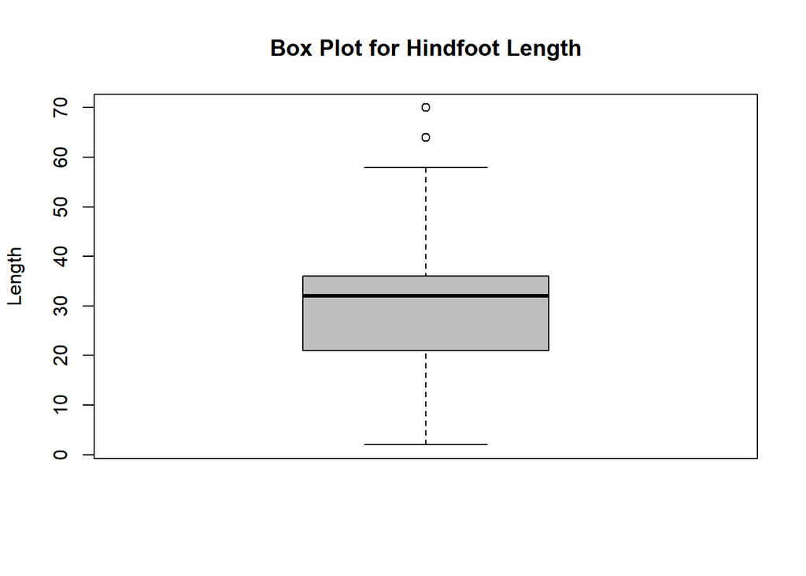

```r
outliers_hindfoot_length <- boxplot(surveys_combined$hindfoot_length,
                                    main = "Box Plot for Hindfoot Length",
                                    ylab = "Length",
                                    col = "grey")
```

```r
outliers_hindfoot_length$out
```

```
## [1] 70 64
```

**Step 2:** In this step, we dealt with outlying value 70. First we checked the record where `hindfoot_length` was 70. From the output, this record belongs to `albigula` species.

```r
surveys_combined %>% filter(hindfoot_length == 70)
```

| record_id | month | day | year | species_id | sex | hindfoot_length | weight | genus | species | taxa |
| --- | --- | --- | --- | --- | --- | --- | --- | --- | --- | --- |
| 10574 | 7 | 23 | 1985 | NL |  | 70 | NA | Neotoma | albigula | Rodent |

We then used `hist()` function from `graphics` package to plot the frequency distribution of `hindfoot_length` for species `albigula`. We also calculated the descriptive statistics for `hindfoot_legth` uing `summary()` function from `base` package.

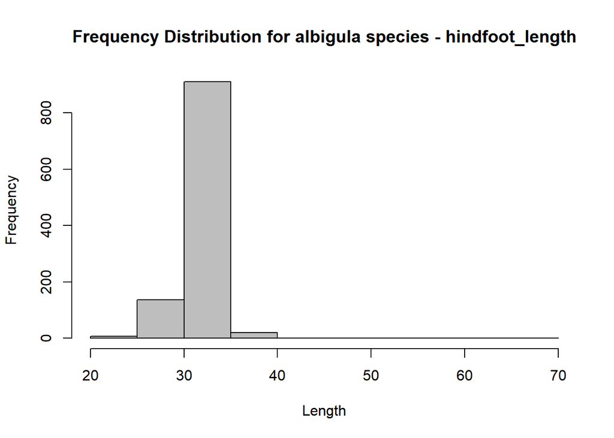

```r
(surveys_combined %>% filter(species == "albigula"))$hindfoot_length %>%
                      hist(main = "Frequency Distribution for albigula species - hindfoot_length",
                      xlab = "Length",
                      ylab = "Frequency",
                      col = "grey")
```

```r
(surveys_combined %>% filter(species == "albigula"))$hindfoot_length %>% summary()
```

```
##    Min. 1st Qu.  Median    Mean 3rd Qu.    Max.    NA's
##   21.00   31.00   32.00   32.29   33.00   70.00     178
```

From the graph, we observed that majority of the values were between 30 to 35 and there are hardly any values near 70. Also, from the descriptive statistic values, median is at 32 and 3rd quartile value is 33, i.e., 75% of values are less than 33.

As the count of values near 70 is very less, the outlying value of 70 seems to be data entry or measurement error. We then decided to exclude this value from `surveys_combined`.

We excluded the record from `surveys_combined` using below code. From the output, number of rows in `surveys_combined` has decreased by 1. This means that the record having `hindfoot_length` = `70` has been removed from `surveys_combined`.

```r
#Calculating outlier location
outlier_70_location <- which(surveys_combined$hindfoot_length == 70)

#Checking row count before deleting outlier
surveys_combined %>% filter(species == "albigula") %>% nrow()
```

```
## [1] 1252
```

```r
#Deleting the outlier
surveys_combined <- surveys_combined[-c(outlier_70_location),]

#Checking row count after deleting outlier
surveys_combined %>% filter(species == "albigula") %>% nrow()
```

```
## [1] 1251
```

**Step 3:** In this step, we dealt with outlying value 64. Then we checked the record where `hindfoot_length` was 64. From the output, this record belongs to `ordii` species.

```r
surveys_combined %>% filter(hindfoot_length == 64)
```

| record_id | month | day | year | species_id | sex | hindfoot_length | weight | genus | species | taxa |
| --- | --- | --- | --- | --- | --- | --- | --- | --- | --- | --- |
| 30425 | 3 | 4 | 2000 | DO | F | 64 | 35 | Dipodomys | ordii | Rodent |

Like in previous step, we used `hist()` function from `graphics` package to plot the frequency distribution of `hindfoot_length` for species `ordii`. We then calculated the descriptive statistics for `hindfoot_legth` using `summary()` function from `base` package.

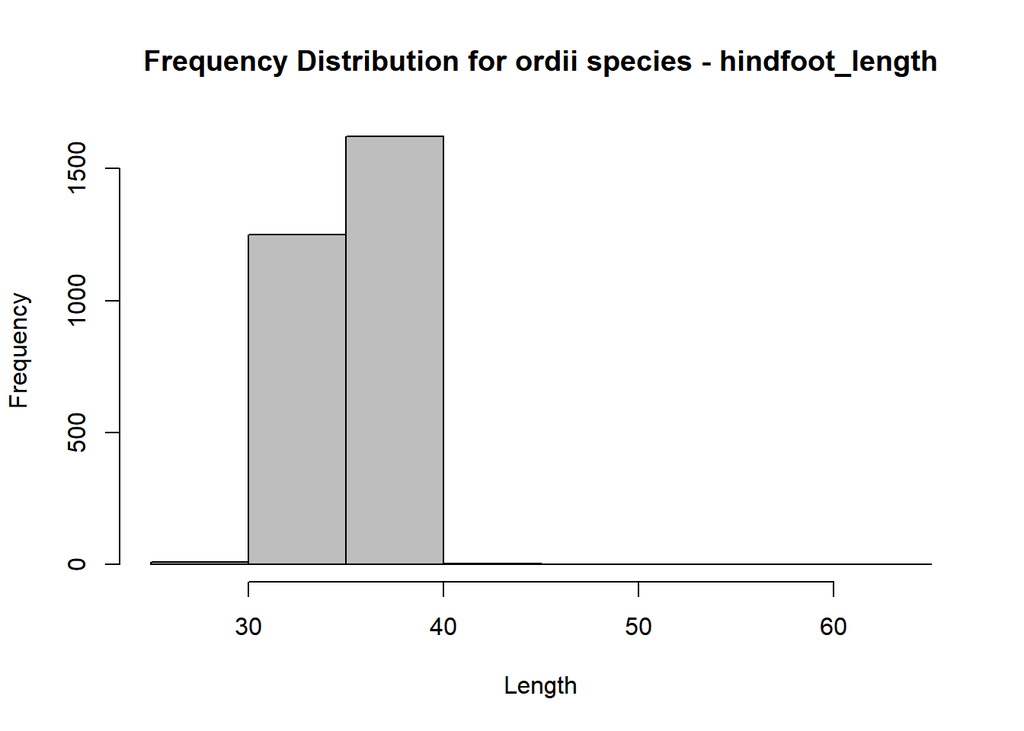

```r
(surveys_combined %>% filter(species == "ordii"))$hindfoot_length %>%
                      hist(main = "Frequency Distribution for ordii species - hindfoot_length",
                      xlab = "Length",
                      ylab = "Frequency",
                      col = "grey")
```

```r
(surveys_combined %>% filter(species == "ordii"))$hindfoot_length %>% summary()
```

```
##    Min. 1st Qu.  Median    Mean 3rd Qu.    Max.    NA's
##   26.00   35.00   36.00   35.61   37.00   64.00     140
```

From the graph, we observed that majority of the values were between 30 to 40 and there are hardly any values near 64. Also, from the descriptive statistic values, median is at 36 and 3rd quartile value is 37, i.e., 75% of values are less than 37.

Similar to previous step, the count of values near 64 being very less, the outlying value of 64 seems to be data entry or measurement error. We therefore decided to exclude this value too from `surveys_combined`.

We excluded the record from `surveys_combined` using below code. From the output, number of rows in `surveys_combined` has decreased by 1. This means that the record having `hindfoot_length` = `64` too has been removed from `surveys_combined`.

```r
#Calculating outlier location
outlier_64_location <- which(surveys_combined$hindfoot_length == 64)

#Checking row count before deleting outlier
surveys_combined %>% filter(species == "ordii") %>% nrow()
```

```
## [1] 3027
```

```r
#Deleting the outlier
surveys_combined <- surveys_combined[-c(outlier_64_location),]

#Checking row count after deleting outlier
surveys_combined %>% filter(species == "ordii") %>% nrow()
```

```
## [1] 3026
```

We again replotted the box plot for `hindfoot_length`. From the output, the outliers were successfully removed.

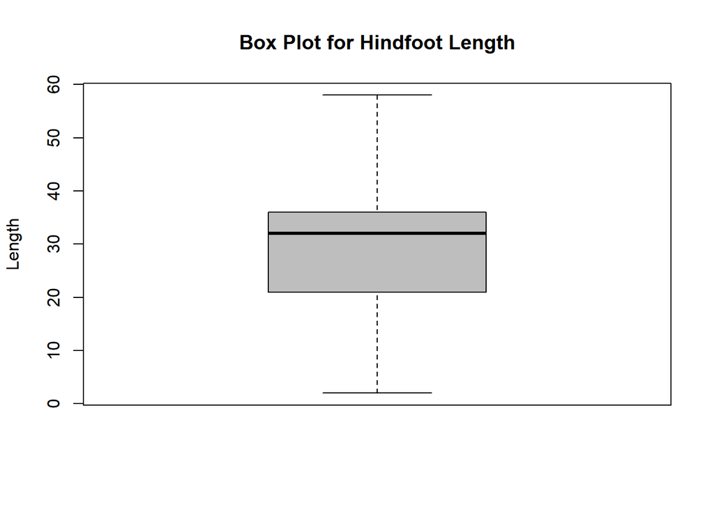

```r
boxplot(surveys_combined$hindfoot_length,
        main = "Box Plot for Hindfoot Length",
        ylab = "Length",
        col = "grey")
```

This also tells us that removing the outliers was correct way of handling them. This is because removing outliers changes the descirptive statistics of that variable, `hindfoot_length` in our case. So, if there were other values present near our outlying values, the boxplot which we plotted after removing those outliers should have shown new outliers. From the graph below, that is clearly not the case.

So we safely concluded that exluding outliers was appropriate and outliers were successfully removed from `surveys_combined`.